# DA homework 2 박정명

2022-10-28

# Question 1

## Question 1 a)

```r
df= read.csv("sample_df.csv")

num_trials <- 100
bs_s100_1 <- 1:num_trials %>%
  map_dfr(
    ~df %>% select(s100_1) %>%
      slice_sample(n = 100, replace = TRUE) %>%
      summarize(mean= mean(s100_1))
  )
#Find the mean and se of the resamples
q1a=bs_s100_1 %>%
  skim(mean) %>%
  select(4:5) %>%
  data.frame()

#Since we can assume normality, it is better to use mean plus or minus 2*SE than to find quantiles as this is computationally time-consuming

#Making as functions
conf_fun= function(data){
  ans= data.frame(p2.5= data$mean- 2*data$sd,p97.5=data$mean+2*data$sd)
  return(ans)
}
conf_fun(q1a) #Final answer for question 1a)
```

```
##         p2.5     p97.5
## 1 -0.2702216 0.1215842
```

## Question 1 b)

[output not shown]

[output cut: 144 more lines]

[output not shown]

```
## contain_zero
##    No   Yes
## 0.062 0.938
```

## Question 1c)

```r
df_nest= df %>% tibble() %>%  pivot_longer(cols= starts_with("s"), names_to= "a", values_to = "b") %>%
  group_by(X) %>% nest() %>% mutate(list= map(data,pull, b)) %>%
  select(1,3)


test=df_nest %>% unnest(cols=c("list"))

q1c_final_table=
1:100 %>%
map_dfr(~test %>% slice_sample(n=1000, replace=TRUE) %>% group_by(X) %>% summarise(avg=mean(list))) %>%
  group_by(X) %>%  summarise(bs_mean= mean(avg), bs_std=sd(avg)) %>%
  mutate(p2.5= bs_mean-2*bs_std, p97.5=bs_mean+2*bs_std) %>%
  mutate(contain_zero= ifelse(p2.5*p97.5<=0, "Yes","No"))

q1c_final_table %>% head(5)
```

```
## # A tibble: 5 × 6
##   X          bs_mean bs_std    p2.5   p97.5 contain_zero
##   <chr>        <dbl>  <dbl>   <dbl>   <dbl> <chr>
## 1 s1000_1   -0.0105  0.0371 -0.0848  0.0637 Yes
## 2 s1000_10  -0.00170 0.0295 -0.0608  0.0574 Yes
## 3 s1000_100 -0.0753  0.0290 -0.133  -0.0173 No
## 4 s1000_11  -0.0207  0.0326 -0.0860  0.0445 Yes
## 5 s1000_12   0.0271  0.0326 -0.0381  0.0922 Yes
```

```r
q1c_final_table %>%
  pluck(6) %>% table() %>% prop.table()
```

```
## .
##   No  Yes
## 0.04 0.96
```

## Question 1 d)

Both answers from 1a) and 1c) are somewhat similar. The difference may be due to the difference in sample size; 1a) has sample size of 100 and 1c) has 1000. Due to the central limit theorem, the distribution of 1c) follows a more normal distribution that does 1b) as it has a larger sample size. This may be the reason that it has a higher coverage probability, which is where the confidence interval includes 0. As a note, the samples were likely taken from a normal distribution with mean 0.

## Question 1 e)

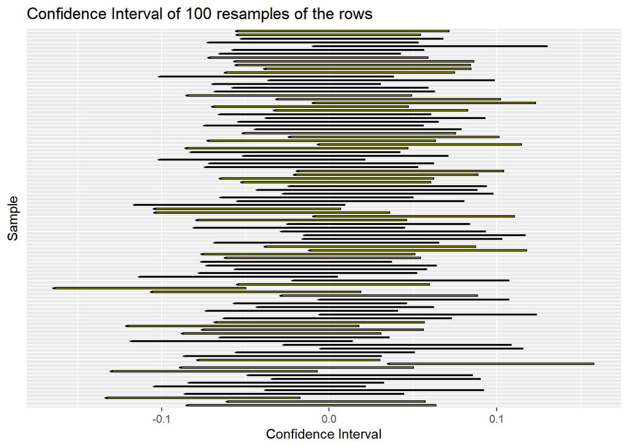

```r
ggplot(q1c_final_table,aes(y=X,x=p2.5))+
  geom_crossbar(aes(xmin=p2.5,xmax=p97.5),width=0.3,fill="YELLOW")+
  labs(x= "Confidence Interval", y="Sample", title="Confidence Interval of 100 resamples of the rows")+
  theme(axis.text.y=element_blank(),
        axis.ticks.y=element_blank())
```

# Question 2

## Question 2 a)

```r
x <- c("one two three", "four five six", "SEVEN EIGHT")


second_word=function(x){
  x %>% map_chr(~word(.,2))
}

second_word(x)
```

```
## [1] "two"   "five"  "EIGHT"
```

## Question 2 b)

```r
url="https://en.wikipedia.org/wiki/Fields_Medal"
table= url %>%
  read_html() %>%
  html_nodes("table") %>%
  pluck(2) %>%
  html_table()


cond = function(x){
  switch(as.character(x), "his"="his", "her"="her", "other")
}


table %>%  pluck(6) %>% map_chr(~second_word(.)) %>%
  map_chr(~cond(.)) %>%
  table()
```

```
## .
##   her   his other
##     1    14    49
```

## Question 2 c)

```r
#First we need to join Year and Medalist as this forms a composite key with unique values
table %>%
  mutate(ID= paste(Year,`Medalists[20]`)) %>%
  unnest_tokens(word,Reasons) %>%
  anti_join(get_stopwords(), by = "word") %>%
  count(ID, word, sort = TRUE)%>%
  group_by(word) %>%
  summarise(count= sum(n)) %>%
  arrange(desc(count)) %>%
  filter( !word %in% c("theory","contributions","proof")) %>%
  head(3)
```

```
## # A tibble: 3 × 2
##   word         count
##   <chr>        <int>
## 1 geometry        19
## 2 algebraic       16
## 3 differential    15
```

# Question 3

```r
setwd("C:/Users/user/Documents/School/Year 3/Semester 2/Data Analysis/Data Analysis Homework/DA HW2")
hn19= read_sas("HN19_ALL.sas7bdat")
```

## Question 3a)

## DATA WRANGLING

In the analysis, we focused on HE_chol, HE_sbp, HE_dbp variables.  
HE_chol: 총콜레스테롤  
HE_sbp: 최종 수축기 혈압(2,3차 평균) - systolic blood pressure  
HE_dbp: 최종 이완기 혈압(2,3차 평균) - diabolic blood pressure

Question: Does increasing cholesterol consumption increase SBP and DBP?

```r
hn19_chol =hn19 %>%
  filter(!is.na(HE_chol)) %>%
  filter(HE_chol>100) %>%
  mutate(HE_chol_cat= cut(HE_chol, breaks= c(0,200,240,Inf),labels= c("Desirable", "Borderline High", "High"))) %>%
  mutate(HE_sbp_cat= cut(HE_sbp, breaks= c(0,130, Inf),labels = c("Low","High"))) %>%
  mutate(HE_dbp_cat= cut(HE_dbp, breaks= c(0,80, Inf),labels = c("Low","High")))

hn19_chol_detail =hn19 %>%
  filter(!is.na(HE_chol)) %>%
  filter(HE_chol>100) %>%
  mutate(HE_chol_cat= cut(HE_chol, breaks= c(0,200,240,Inf),labels= c("Desirable", "Borderline High", "High"))) %>%
  mutate(HE_sbp_cat= cut(HE_sbp, breaks= c(0,90,120,130,140, Inf),labels = c("Low","Normal","Elevated","High BP(Stage 1)","High BP(Stage 2)"))) %>%
  mutate(HE_dbp_cat= cut(HE_dbp, breaks= c(0,60,70,80,90, Inf),labels = c("Low","Normal","Elevated","High BP(Stage 1)","High BP(Stage 2)")))
```

To help with analysis, we created new variables:  
HE_chol_cat: 총콜레스테롤 수치변수를 cut()을 이용해 변수형 데이터로 변경함  
HE_sbp_cat: 수축기 혈압 수치변수를 cut()을 이용해 변수형 데이터로 변경함  
HE_dbp_cat: 이완기 혈압 수치변수를 cut()을 이용해 변수형 데이터로 변경함

HE_chol_cat are divided as shown in the picture below:

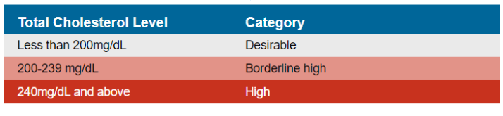

*hn19_chol* data frame is used for the scatter plots below. HE_sbp_cat and HE_dbp_cat only divide at 130 and 80, respectively. These values are the minimum blood pressure in mmHg for high SBP and DBP set by the 2017 American College of Cardiology/American Heart Association Blood Pressure Guidelines.  
*hn19_chol_detail* data frame is used for the stacked bar graph plots below. As will be shown below in the scatter plots, it’s hard to show the change in proportion with a line across the y-intercept, so we will use a stacked bar graph to see the whether people have higher blood pressure with more cholesterol consumption.

For hn19_chol_detail, the HE_sbp_cat and HE_dbp_cat are further divded as shown in the picture below:

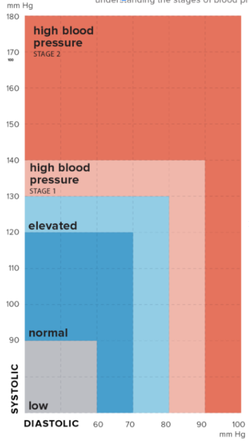

## SCATTER GRAPH

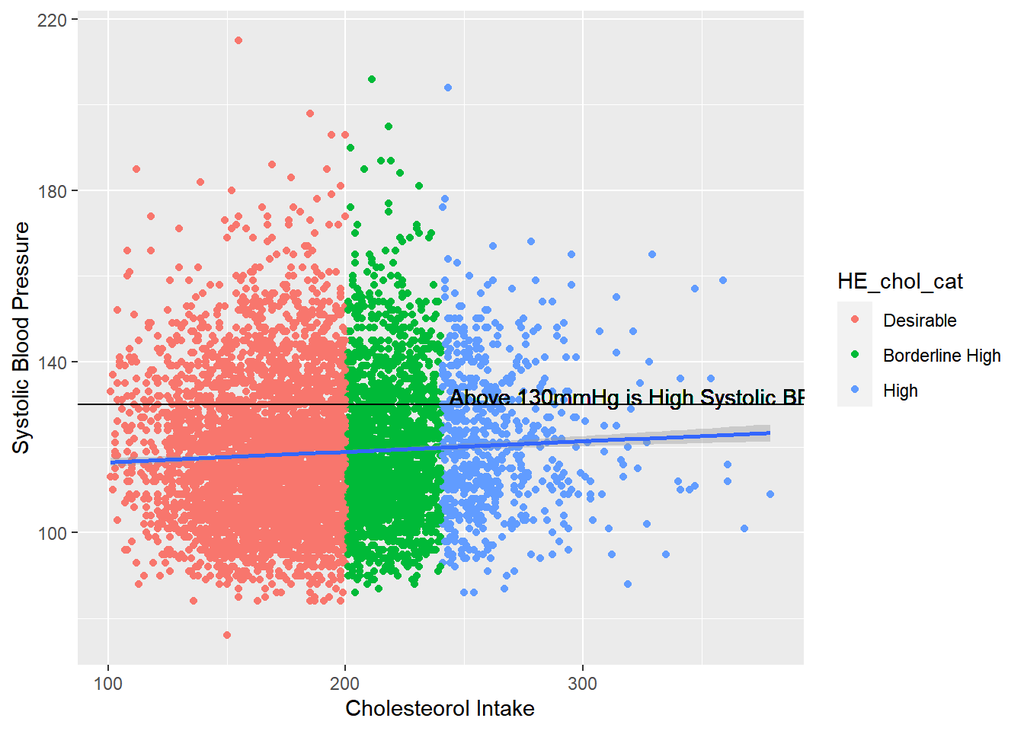

```r
#3a)
## CHOLESTEROL VS SBP SCATTER GRAPH
  ggplot(hn19_chol, aes(HE_chol, HE_sbp))+
    geom_point(aes(color= HE_chol_cat))+
    geom_hline(yintercept = 130)+
    geom_text(x=320, y=132, label= "Above 130mmHg is High Systolic BP")+
    geom_smooth(method=lm,se=TRUE)+
  labs(x="Cholesteorol Intake", y= "Systolic Blood Pressure")
```

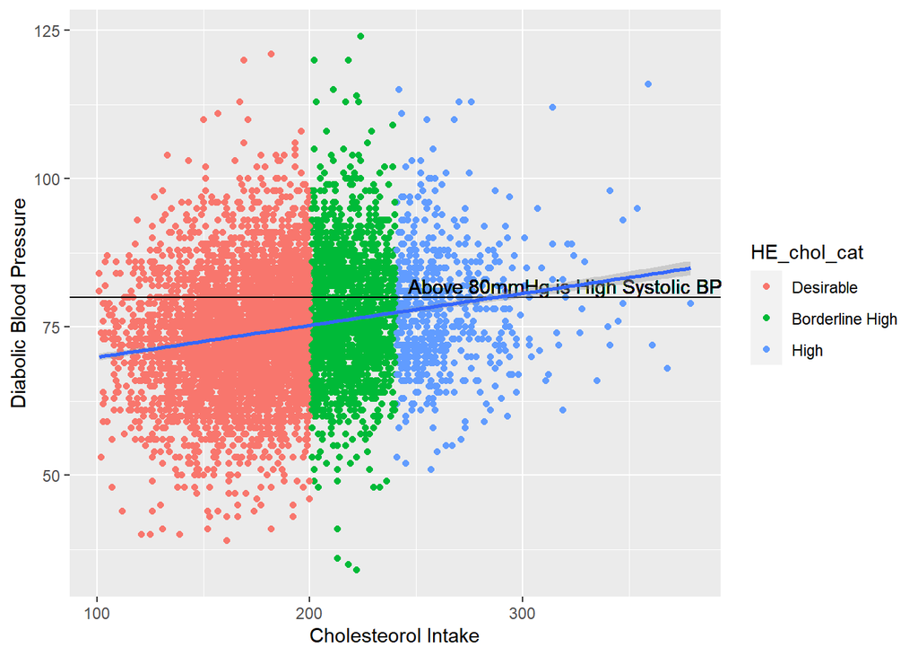

```r
## CHOLESTEROL VS DBP  SCATTER GRAPH
#3c)

ggplot(hn19_chol, aes(HE_chol, HE_dbp))+
  geom_point(aes(color= HE_chol_cat))+
  geom_hline(yintercept = 80)+
  geom_text(x=320, y=82, label= "Above 80mmHg is High Systolic BP")+
  geom_smooth(method=lm,se=TRUE)+
  labs(x="Cholesteorol Intake", y= "Diabolic Blood Pressure")
```

```r
summary(lm(data=hn19_chol, HE_chol~HE_sbp))
```

```
##
## Call:
## lm(formula = HE_chol ~ HE_sbp, data = hn19_chol)
##
## Residuals:
##     Min      1Q  Median      3Q     Max
## -91.170 -26.546  -1.989  23.486 189.978
##
## Coefficients:
##              Estimate Std. Error t value Pr(>|t|)
## (Intercept) 174.72479    3.37009  51.846  < 2e-16 ***
## HE_sbp        0.13116    0.02812   4.664 3.16e-06 ***
## ---
## Signif. codes:  0 '***' 0.001 '**' 0.01 '*' 0.05 '.' 0.1 ' ' 1
##
## Residual standard error: 37.79 on 6719 degrees of freedom
##   (30 observations deleted due to missingness)
## Multiple R-squared:  0.003227,   Adjusted R-squared:  0.003079
## F-statistic: 21.75 on 1 and 6719 DF,  p-value: 3.158e-06
```

```r
summary(lm(data=hn19_chol, HE_chol~HE_dbp))
```

```
##
## Call:
## lm(formula = HE_chol ~ HE_dbp, data = hn19_chol)
##
## Residuals:
##     Min      1Q  Median      3Q     Max
## -96.298 -25.650  -2.256  23.054 185.505
##
## Coefficients:
##              Estimate Std. Error t value Pr(>|t|)
## (Intercept) 133.41055    3.38662   39.39   <2e-16 ***
## HE_dbp        0.76056    0.04487   16.95   <2e-16 ***
## ---
## Signif. codes:  0 '***' 0.001 '**' 0.01 '*' 0.05 '.' 0.1 ' ' 1
##
## Residual standard error: 37.07 on 6719 degrees of freedom
##   (30 observations deleted due to missingness)
## Multiple R-squared:  0.041,  Adjusted R-squared:  0.04086
## F-statistic: 287.3 on 1 and 6719 DF,  p-value: < 2.2e-16
```

Linear regression of HE_chol against HE_sbp has p_value that is very small so significantly significant.  
Linear regression of HE_chol against HE_dbp has p_value that is very small so significantly significant.

## STACKED BAR GRAPH TO COMPARE PROPORTIONS

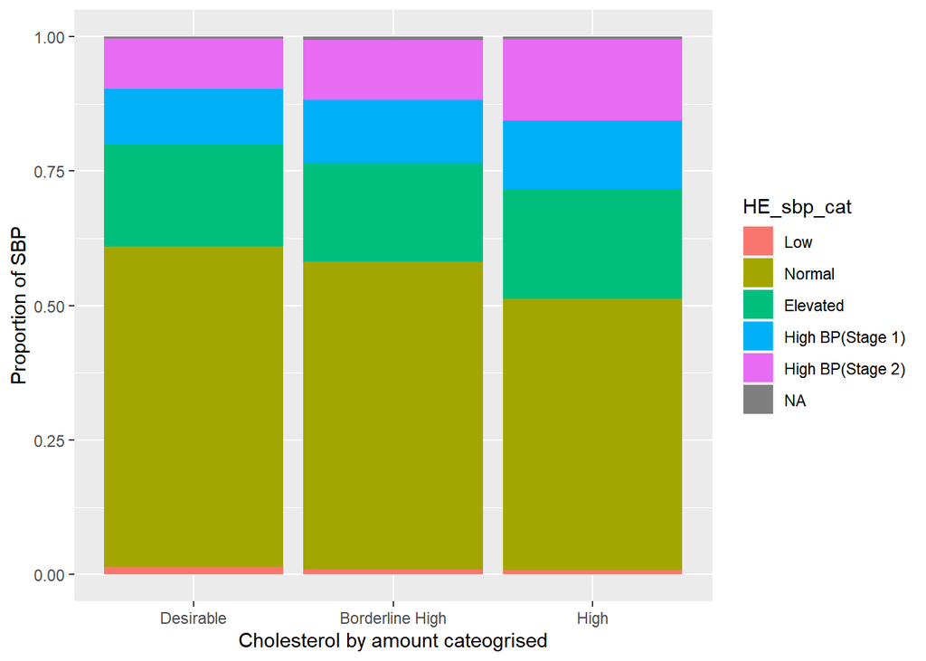

```r
#3a)
## CHOLESTEROL VS SBP STACKED BAR GRAPH
ggplot(hn19_chol_detail,aes(HE_chol_cat,fill=HE_sbp_cat))+
  geom_bar(position= position_fill(reverse=TRUE))+
  labs(x="Cholesterol by amount cateogrised", y= "Proportion of SBP")
```

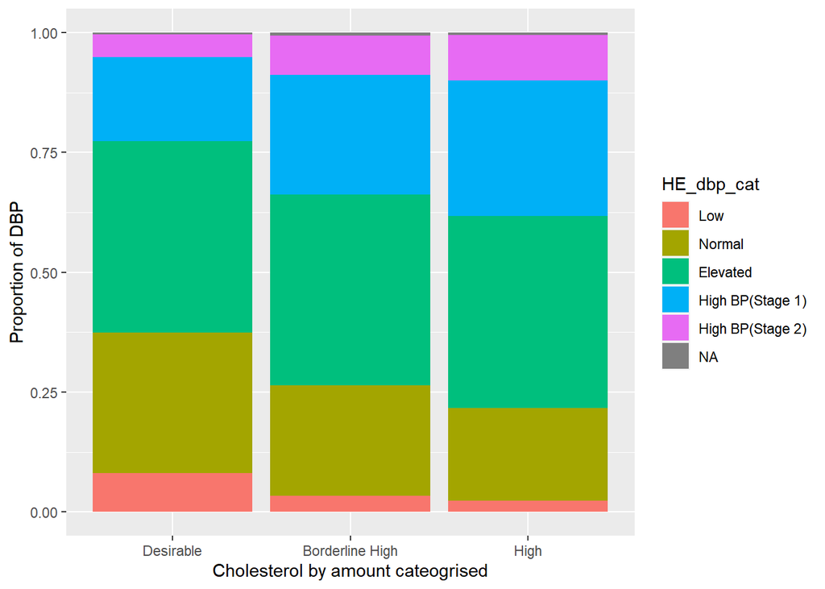

```r
#3c)
  ## CHOLESTEROL VS DBP STACKED BAR GRAPH
  ggplot(hn19_chol_detail,aes(HE_chol_cat,fill=HE_dbp_cat))+
    geom_bar(position= position_fill(reverse=TRUE))+
    labs(x="Cholesterol by amount cateogrised", y= "Proportion of DBP")
```

We can see from the stacked bar graphs that as the choelesteroal intake increases, the proportion of high SBP and DBP both increases. This is observed for both SBP and DBP.

## Question 3 b)

Referencing, paper called: “Combined effects of systolic blood pressure and serum cholesterol on cardiovascular mortality in young ( <55 years) men and women”

The paper shows that Blood pressure (BP) and cholesterol are major risk factors for cardiovascular disease and that cholesteorl increases both systolic and diaboli blood pressure. In men, high cholesterol was found twice as much in hypertensives than in normotensives; in women, it was more than three times higher. Both cholesterol and high blood pressure were a risk factors for cardiovascular disease and coronary heart disease. According to the research paper alluded bleow, in men, a borderline elevation of both systolic blood pressure (130-139 mmHg) and cholesterol (200-239 mg x dl(-1)) leads to a three- to four-fold increase in cardiovascular disease risk. Men with systolic blood pressure >or=160 mmHg represent a small percentage (about 5%) who have a 10-fold increase in cardiovascular disease and coronary heart disease risk, especially when high cholesterol is present. The paper is in accordance to our result: higher cholesterol increases the higher SBP and DBP, which in turn increase the chance of cardiobascualr disease.